# CALPM

- Show All Code
- Hide All Code
- View Source

Author

Grupa 1

# 1 Czyszczenie i eksporacja danych

## 1.1 Setup

**Show and hide code**

```r
library(tidyverse)
library(dplyr)
library(tibble)
library(purrr)
library(stringr)
library(lubridate)
library(ggplot2)
library(corrplot)
library(patchwork)
library(vip)
library(knitr)
library(tidymodels)
library(rsample)
library(recipes)
library(parsnip)
library(workflows)
library(workflowsets)
library(broom)
library(xgboost)
library(kernlab)
library(glmnet)
library(car)
library(tictoc)
library(e1071)

tidymodels_prefer()
set.seed(123)
```

## 1.2 Załadowanie danych

**Show and hide code**

```r
load("dane/ops.RData")
ops <- ops |> na.omit()
ops <- ops |> select(-ops_pm10, -pres_sea)
```

## 1.3 Podstawowe sprawdzenie danych

**Show and hide code**

```r
colSums(is.na(ops))
```

```
      date grimm_pm10     n_0044     n_0075     n_0100     n_0120     n_0140
         0          0          0          0          0          0          0
    n_0200     n_0250     n_0500     n_0750     n_1000       temp         rh
         0          0          0          0          0          0          0
      pres         wd        mws         ws       prec
         0          0          0          0          0
```

**Show and hide code**

```r
summary(ops)
```

```
      date                         grimm_pm10         n_0044
 Min.   :2022-01-21 11:00:00.0   Min.   :  2.90   Min.   :  4.178
 1st Qu.:2022-02-01 11:30:00.0   1st Qu.: 16.05   1st Qu.: 24.237
 Median :2022-02-10 10:00:00.0   Median : 32.00   Median : 55.757
 Mean   :2022-02-10 08:51:32.9   Mean   : 42.24   Mean   :101.460
 3rd Qu.:2022-02-19 08:30:00.0   3rd Qu.: 60.40   3rd Qu.:133.716
 Max.   :2022-02-28 07:00:00.0   Max.   :215.40   Max.   :765.292
     n_0075             n_0100             n_0120            n_0140
 Min.   :  0.7276   Min.   : 0.08575   Min.   :0.01945   Min.   :0.01415
 1st Qu.:  5.8932   1st Qu.: 0.79841   1st Qu.:0.16747   1st Qu.:0.10478
 Median : 11.0323   Median : 1.31703   Median :0.29303   Median :0.18307
 Mean   : 21.1516   Mean   : 1.86505   Mean   :0.36645   Mean   :0.21861
 3rd Qu.: 24.9082   3rd Qu.: 2.32868   3rd Qu.:0.48849   3rd Qu.:0.27744
 Max.   :215.5690   Max.   :14.40541   Max.   :2.05866   Max.   :1.12680
     n_0200            n_0250             n_0500            n_0750
 Min.   :0.03216   Min.   :0.009057   Min.   :0.01447   Min.   :0.0006842
 1st Qu.:0.21615   1st Qu.:0.045889   1st Qu.:0.06229   1st Qu.:0.0063144
 Median :0.38556   Median :0.090510   Median :0.14289   Median :0.0167398
 Mean   :0.46225   Mean   :0.131563   Mean   :0.23658   Mean   :0.0310844
 3rd Qu.:0.58813   3rd Qu.:0.173393   3rd Qu.:0.29847   3rd Qu.:0.0393332
 Max.   :1.99174   Max.   :0.807703   Max.   :1.71827   Max.   :0.2584242
     n_1000               temp              rh             pres
 Min.   :0.0002004   Min.   :-7.650   Min.   :19.32   Min.   : 962.0
 1st Qu.:0.0022873   1st Qu.: 1.462   1st Qu.:53.52   1st Qu.: 982.6
 Median :0.0058276   Median : 3.190   Median :62.06   Median : 988.7
 Mean   :0.0112202   Mean   : 3.609   Mean   :60.46   Mean   : 988.9
 3rd Qu.:0.0139448   3rd Qu.: 5.791   3rd Qu.:70.18   3rd Qu.: 996.3
 Max.   :0.0975555   Max.   :13.985   Max.   :80.52   Max.   :1008.5
       wd             mws               ws              prec
 Min.   :  1.0   Min.   : 0.600   Min.   :0.3433   Min.   :0.0000
 1st Qu.:246.0   1st Qu.: 2.500   1st Qu.:1.2433   1st Qu.:0.0000
 Median :262.0   Median : 4.100   Median :2.2967   Median :0.0000
 Mean   :251.8   Mean   : 4.327   Mean   :2.4322   Mean   :0.0237
 3rd Qu.:280.0   3rd Qu.: 5.700   3rd Qu.:3.2575   3rd Qu.:0.0000
 Max.   :359.0   Max.   :13.700   Max.   :7.2967   Max.   :6.1633
```

**Show and hide code**

```r
glimpse(ops)
```

```
Rows: 859
Columns: 19
$ date       <dttm> 2022-01-21 11:00:00, 2022-01-21 12:00:00, 2022-01-21 13:00…
$ grimm_pm10 <dbl> 19.4, 12.6, 14.2, 20.3, 13.9, 14.3, 18.1, 22.6, 23.4, 21.9,…
$ n_0044     <dbl> 57.31487, 30.48457, 29.52310, 34.83708, 32.16161, 42.76850,…
$ n_0075     <dbl> 13.583416, 7.921950, 7.318594, 8.273678, 7.905023, 9.997945…
$ n_0100     <dbl> 1.722106, 1.221410, 1.097107, 1.128687, 1.018163, 1.123111,…
$ n_0120     <dbl> 0.3620380, 0.2946828, 0.2770578, 0.2829772, 0.2481288, 0.26…
$ n_0140     <dbl> 0.2277054, 0.1917834, 0.1777918, 0.1784637, 0.1571229, 0.15…
$ n_0200     <dbl> 0.4588658, 0.4203183, 0.4098838, 0.3929689, 0.3423779, 0.33…
$ n_0250     <dbl> 0.09386431, 0.09209425, 0.09982402, 0.07900083, 0.06974166,…
$ n_0500     <dbl> 0.13998488, 0.12950709, 0.14115179, 0.10639199, 0.08824277,…
$ n_0750     <dbl> 0.015905973, 0.013818738, 0.014947178, 0.011131220, 0.00803…
$ n_1000     <dbl> 0.006277655, 0.004624687, 0.005361134, 0.003574368, 0.00302…
$ temp       <dbl> -1.34166667, -1.62666667, -1.96000000, -2.00166667, -1.4883…
$ rh         <dbl> 67.05167, 67.97667, 67.01333, 65.09667, 55.92667, 63.81500,…
$ pres       <dbl> 990.2600, 990.1100, 990.1800, 990.4000, 990.3817, 990.6700,…
$ wd         <dbl> 273, 281, 284, 288, 290, 262, 273, 259, 265, 257, 273, 277,…
$ mws        <dbl> 6.5, 6.5, 6.2, 5.7, 6.4, 4.7, 4.4, 4.7, 3.6, 4.5, 4.3, 4.5,…
$ ws         <dbl> 3.3450000, 3.9966667, 3.7816667, 3.3116667, 3.7083333, 2.58…
$ prec       <dbl> 0, 0, 0, 0, 0, 0, 0, 0, 0, 0, 0, 0, 0, 0, 0, 0, 0, 0, 0, 0,…
```

## 1.4 Podzielenie zbioru

**Show and hide code**

```r
ops <-  ops |>
  mutate(
    hour = lubridate::hour(date),
    wday = lubridate::wday(date, label = FALSE, week_start = 1)  # Monday = 1
  )
split <- initial_time_split(ops, prop = 0.7)
train <- training(split)
test <- testing(split)
```

Dane dzielone są na zbiór uczący (70%) i testowy (30%). Dodatkowo tworzona jest informacja o godzinie i dniu tygodnia.

## 1.5 Obsługa wartości odstających

**Show and hide code**

```r
# Identyfikacja wartości odstających za pomocą rozkładu międzykwartylowego
detect_outliers <- function(x) {
  q1 <- quantile(x, 0.25, na.rm = TRUE)
  q3 <- quantile(x, 0.75, na.rm = TRUE)
  iqr <- q3 - q1
  lower <- q1 - 3 * iqr
  upper <- q3 + 3 * iqr # Konserwatywne przyjęcie

  n_lower <- sum(x < lower, na.rm = TRUE)
  n_upper <- sum(x > upper, na.rm = TRUE)
  pct_outliers <- (n_lower + n_upper) / length(x) * 100

  tibble(lower = lower, upper = upper,
         n_lower = n_lower, n_upper = n_upper,
         pct_outliers = round(pct_outliers, 2))
}

numeric_cols <- train %>% select(where(is.numeric), -wd) %>% names()

outlier_summary <- train %>%
  summarise(across(all_of(numeric_cols), detect_outliers)) %>%
  pivot_longer(everything(), names_to = "variable", values_to = "stats") %>%
  unnest(stats) %>%
  arrange(desc(pct_outliers))

print("Wartości odstające")
```

```
[1] "Wartości odstające"
```

**Show and hide code**

```r
print(outlier_summary %>% filter(pct_outliers > 0))
```

```
# A tibble: 11 × 6
   variable     lower    upper n_lower n_upper pct_outliers
   <chr>        <dbl>    <dbl>   <int>   <int>        <dbl>
 1 prec        0        0            0     113        18.8
 2 n_0075    -54.5     88.4          0      23         3.83
 3 n_0100     -3.73     6.97         0      20         3.33
 4 n_1000     -0.0360   0.0521       0      17         2.83
 5 n_0750     -0.102    0.148        0      15         2.5
 6 n_0044   -340.     526.           0      13         2.16
 7 n_0500     -0.672    1.02         0      13         2.16
 8 n_0120     -0.834    1.50         0      12         2
 9 n_0250     -0.359    0.576        0      11         1.83
10 n_0140     -0.443    0.828        0       9         1.5
11 n_0200     -0.978    1.78         0       7         1.16
```

## 1.6 Analiza skośności

Ze względu na bardzo wysoką skośność prawostronną konieczne jest zastosowanie transformacji Yeo-Johnsona

**Show and hide code**

```r
numeric_cols <- train %>% select(where(is.numeric), -wd) %>% names()

skew_tbl <- train %>%
  summarise(across(all_of(numeric_cols), ~skewness(.x, na.rm = TRUE, type = 2))) %>%
  pivot_longer(everything(), names_to = "Zmienne", values_to = "Skosnosc") %>%
  arrange(desc(abs(Skosnosc)))

print(skew_tbl)
```

```
# A tibble: 19 × 2
   Zmienne    Skosnosc
   <chr>         <dbl>
 1 prec       21.5
 2 n_0075      3.06
 3 n_0100      2.93
 4 n_0120      2.32
 5 n_0044      2.27
 6 n_0750      2.13
 7 n_0500      2.08
 8 n_1000      2.08
 9 n_0140      1.97
10 n_0250      1.83
11 n_0200      1.62
12 grimm_pm10  1.33
13 rh         -0.864
14 ws          0.591
15 mws         0.499
16 pres       -0.203
17 temp        0.198
18 wday        0.145
19 hour        0.00318
```

## 1.7 Analiza korelacji

Z par zmiennych objaśniających o wspólczynniku korelacji powyżej 0.9 zostanie usunięta zmienna, która mniej koreluje ze zmienną objąsnianą.

**Show and hide code**

```r
zliczenia <- train %>% select(starts_with("n_")) %>% names()
target <- "grimm_pm10"
thr <- 0.9

# Zliczenia oraz zmienne dotyczące wiatru
preds <- c(zliczenia, "ws", "mws") %>% .[. %in% names(train)]

# Korelacja
cor_mat <- cor(train[, preds], use = "pairwise.complete.obs", method = "spearman")
tgt_cor <- abs(cor(train[, preds], train[[target]], use = "pairwise.complete.obs", method = "spearman"))

# Identyfikacja silnie skorelowanych zmiennych
pairs_df <- as.data.frame(as.table(cor_mat)) %>%
  as_tibble() %>%
  transmute(var1 = as.character(Var1), var2 = as.character(Var2), corr = Freq) %>%
  filter(var1 != var2) %>%
  mutate(pair = paste(pmin(var1, var2), pmax(var1, var2), sep = "__")) %>%
  distinct(pair, .keep_all = TRUE) %>%
  mutate(abs_corr = abs(corr),
         tgt1 = tgt_cor[var1, 1],
         tgt2 = tgt_cor[var2, 1],
         drop_candidate = if_else(tgt1 <= tgt2, var1, var2)) %>%
  filter(abs_corr > thr) %>%
  arrange(desc(abs_corr))


to_drop <- unique(pairs_df$drop_candidate)

print(to_drop)
```

```
[1] "n_1000" "n_0120" "ws"     "n_0100" "n_0250" "n_0750" "n_0200" "n_0075"
```

**Show and hide code**

```r
print(pairs_df)
```

```
# A tibble: 9 × 8
  var1   var2    corr pair           abs_corr  tgt1  tgt2 drop_candidate
  <chr>  <chr>  <dbl> <chr>             <dbl> <dbl> <dbl> <chr>
1 n_1000 n_0750 0.988 n_0750__n_1000    0.988 0.777 0.784 n_1000
2 n_0140 n_0120 0.972 n_0120__n_0140    0.972 0.735 0.725 n_0120
3 mws    ws     0.970 mws__ws           0.970 0.717 0.714 ws
4 n_0120 n_0100 0.967 n_0100__n_0120    0.967 0.725 0.701 n_0100
5 n_0500 n_0250 0.964 n_0250__n_0500    0.964 0.824 0.821 n_0250
6 n_0750 n_0500 0.957 n_0500__n_0750    0.957 0.784 0.824 n_0750
7 n_0200 n_0140 0.957 n_0140__n_0200    0.957 0.734 0.735 n_0200
8 n_0075 n_0044 0.949 n_0044__n_0075    0.949 0.742 0.764 n_0075
9 n_1000 n_0500 0.928 n_0500__n_1000    0.928 0.777 0.824 n_1000
```

## 1.8 Budowa przepisu

**Show and hide code**

```r
rec <- recipe(grimm_pm10 ~ ., data = train) %>%
  update_role(date, new_role = "id") %>%
  step_mutate(
    hour_s = sin(2*pi*as.numeric(hour)/24),
    hour_c = cos(2*pi*as.numeric(hour)/24),
    wday_s = sin(2*pi*as.numeric(wday)/7),
    wday_c = cos(2*pi*as.numeric(wday)/7)
  ) %>%
  step_rm(hour, wday)

rec <- rec %>% step_rm(all_of(to_drop))

rec <- rec %>%
  step_YeoJohnson(all_numeric_predictors()) %>%
  step_normalize(all_numeric_predictors()) %>%
  step_zv(all_predictors())

rec_prep <- prep(rec, training = train)
train_tr <- bake(rec_prep, new_data = NULL)
test_tr <- bake(rec_prep, new_data = test)
```

## 1.9 EDA

### 1.9.1 Zmienna objaśniana

**Show and hide code**

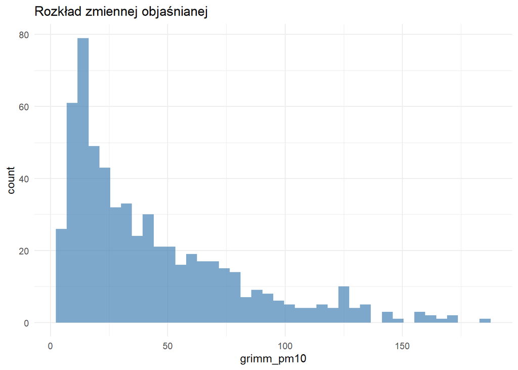

```r
ggplot(train_tr, aes(grimm_pm10)) +
  geom_histogram(bins = 40, fill = "steelblue", alpha = 0.7) +
  labs(title = "Rozkład zmiennej objaśnianej", x = "grimm_pm10") +
  theme_minimal()
```

### 1.9.2 Mapa korelacji

**Show and hide code**

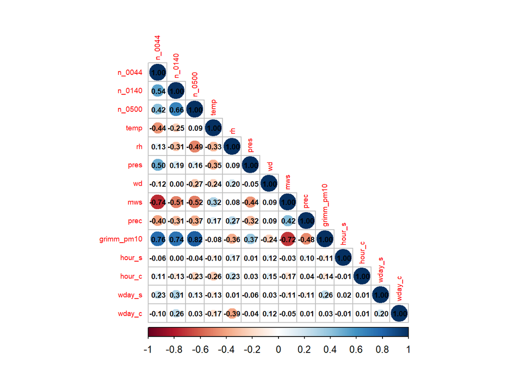

```r
cor_mat_tr <- train_tr %>%
  select(where(is.numeric)) %>%
  cor(use = "pairwise.complete.obs", method = "spearman")

corrplot(cor_mat_tr, type = "lower", tl.cex = 0.6, mar = c(0,0,1,0),
         addCoef.col = "black", number.cex = 0.6, number.digits = 2)
```

### 1.9.3 Najważniejsze predyktory vs zmienna objaśniana

**Show and hide code**

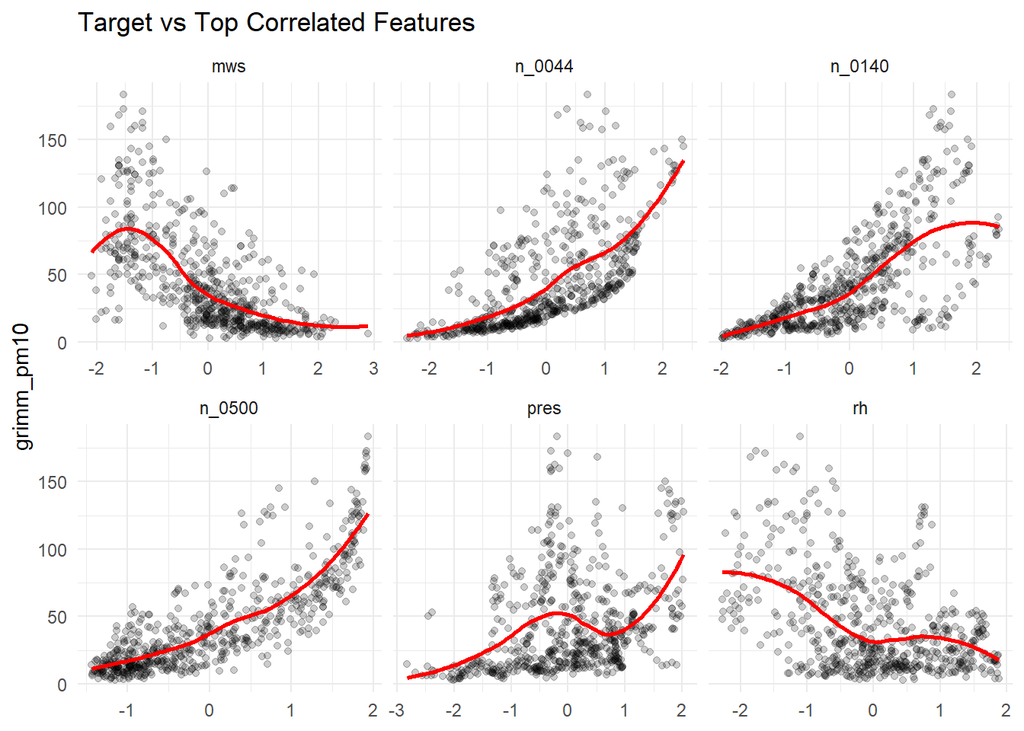

```r
num_pred <- train_tr %>% select(where(is.numeric), -grimm_pm10, -date) %>% names()
tgt_cor_tr <- abs(cor(train_tr[, num_pred], train_tr$grimm_pm10, use = "pairwise.complete.obs"))
top6 <- names(sort(tgt_cor_tr[,1], decreasing = TRUE)[1:6])

train_tr %>%
  select(grimm_pm10, all_of(top6)) %>%
  pivot_longer(all_of(top6), names_to = "feature", values_to = "value") %>%
  ggplot(aes(value, grimm_pm10)) +
  geom_point(alpha = 0.2) +
  geom_smooth(se = FALSE, color = "red") +
  facet_wrap(~ feature, scales = "free_x") +
  labs(title = "Target vs Top Correlated Features", x = NULL) +
  theme_minimal()
```

W modelach regresji liniowych należy uwzględnić nieliniowość relacji.

### 1.9.4 Zmienna objaśniana

**Show and hide code**

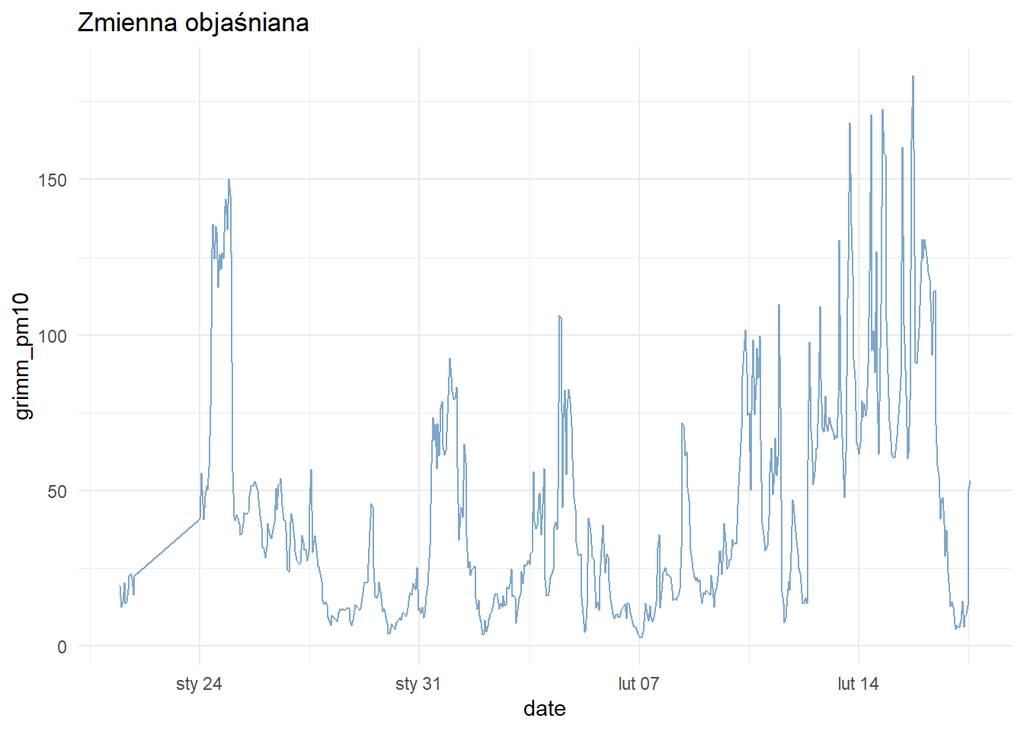

```r
train %>%
  ggplot(aes(date, grimm_pm10)) +
  geom_line(alpha = 0.7, color = "steelblue") +
  labs(title = "Zmienna objaśniana") +
  theme_minimal()
```

## 1.10 Detekcja interakcji

### 1.10.1 Metoda 1: Relacje warunkowe

**Show and hide code**

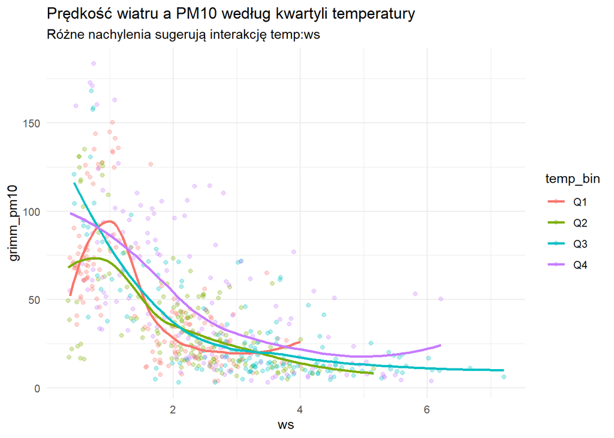

```r
train_int <- train %>%
  mutate(temp_bin = cut(temp, breaks = quantile(temp, probs = seq(0, 1, 0.25), na.rm = TRUE),
                        include.lowest = TRUE, labels = c("Q1", "Q2", "Q3", "Q4")))

ggplot(train_int, aes(ws, grimm_pm10, color = temp_bin)) +
  geom_point(alpha = 0.3) +
  geom_smooth(se = FALSE, method = "loess") +
  labs(title = "Prędkość wiatru a PM10 według kwartyli temperatury",
       subtitle = "Różne nachylenia sugerują interakcję temp:ws") +
  theme_minimal()
```

Dla wyższych wartości temperatur relacja między prędkością wiatru a grimm_pm10 zmienia się.

### 1.10.2 Interakcje między pogodą

**Show and hide code**

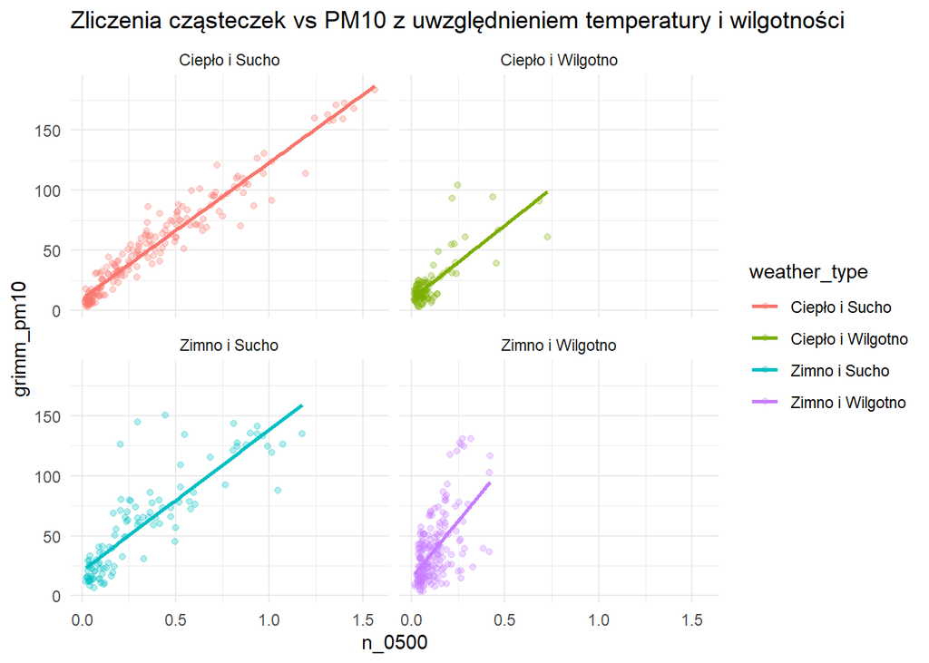

```r
train_weather <- train %>%
  mutate(
    high_rh = rh > median(rh, na.rm = TRUE),
    high_temp = temp > median(temp, na.rm = TRUE),
    weather_type = case_when(
      high_rh & high_temp ~ "Ciepło i Wilgotno",
      high_rh & !high_temp ~ "Zimno i Wilgotno",
      !high_rh & high_temp ~ "Ciepło i Sucho",
      TRUE ~ "Zimno i Sucho"
    )
  )

ggplot(train_weather, aes(n_0500, grimm_pm10, color = weather_type)) +
  geom_point(alpha = 0.3) +
  geom_smooth(se = FALSE, method = "lm") +
  labs(title = "Zliczenia cząsteczek vs PM10 z uwzględnieniem temperatury i wilgotności") +
  theme_minimal() +
  facet_wrap(~weather_type)
```

### 1.10.3 Czasowe interakcje

**Show and hide code**

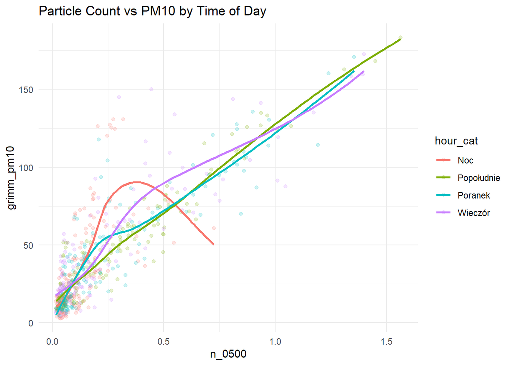

```r
train_time <- train %>%
  mutate(
    hour_cat = case_when(
      hour %in% 0:5 ~ "Noc",
      hour %in% 6:11 ~ "Poranek",
      hour %in% 12:17 ~ "Popołudnie",
      TRUE ~ "Wieczór"
    ),
    weekend = wday %in% c("Sat", "Sun")
  )

ggplot(train_time, aes(n_0500, grimm_pm10, color = hour_cat)) +
  geom_point(alpha = 0.2) +
  geom_smooth(se = FALSE) +
  labs(title = "Particle Count vs PM10 by Time of Day") +
  theme_minimal()
```

## 1.11 Podsumowanie

W ostatecznym przepisie uwzględniono:

- Transformacje trygonometryczne czasu,
- Interakcje między zmiennymi pogodowymi i cząsteczkami,
- Normalizację i transformację Yeo–Johnsona,
- Kodowanie zmiennych kategorycznych.

### 1.11.1 Wyjściowy przepis

**Show and hide code**

```r
rec <- recipe(grimm_pm10 ~ ., data = train) %>%
  update_role(date, new_role = "id") %>%
  step_mutate(
    # Obsługa dni tygodnia i godzin
    hour_s = sin(2*pi*as.numeric(hour)/24),
    hour_c = cos(2*pi*as.numeric(hour)/24),
    wday_s = sin(2*pi*as.numeric(wday)/7),
    wday_c = cos(2*pi*as.numeric(wday)/7),
    # Podział temperatury
    temp_bin = cut(temp,
                   breaks = quantile(temp, probs = seq(0, 1, 0.25), na.rm = TRUE),
                   include.lowest = TRUE, labels = c("Q1", "Q2", "Q3", "Q4")),
    # Typ pogody
    high_rh = rh > median(rh, na.rm = TRUE),
    high_temp = temp > median(temp, na.rm = TRUE),
    weather_type = case_when(
      high_rh & high_temp ~ "warm_humid",
      high_rh & !high_temp ~ "cool_humid",
      !high_rh & high_temp ~ "warm_dry",
      TRUE ~ "cool_dry"
    ),
    # Podział dnia
    hour_cat = case_when(
      as.numeric(hour) %in% 0:5 ~ "night",
      as.numeric(hour) %in% 6:11 ~ "morning",
      as.numeric(hour) %in% 12:17 ~ "afternoon",
      TRUE ~ "evening"
    ),
    weekend = wday %in% c("Sat", "Sun")
  ) %>%
  step_string2factor(weather_type, hour_cat) %>%
  step_rm(hour, wday, high_rh, high_temp)


  rec <- rec %>% step_rm(all_of(to_drop))


# Interakcje
rec <- rec %>%
  step_dummy(all_nominal_predictors()) %>%
  step_interact(~ starts_with("weather_type"):matches("n_0500|n_0250|ws|temp")) %>%
  step_interact(~ starts_with("temp_bin"):matches("n_0500|n_0250|ws")) %>%
  step_interact(~ starts_with("hour_cat"):matches("n_0500|n_0250|ws")) %>%
  step_interact(~ weekend:matches("n_0500|n_0250|ws")) %>%
  step_YeoJohnson(all_numeric_predictors()) %>%
  step_normalize(all_numeric_predictors()) %>%
  step_zv(all_predictors())

rec_prep <- prep(rec, training = train)
train_tr <- bake(rec_prep, new_data = NULL)
test_tr <- bake(rec_prep, new_data = test)

train_main <- train
test_main <- test
to_drop_main <- to_drop
```

# 2 Model XGB

**Show and hide code**

```r
train <- train_main
test <- test_main
to_drop <- to_drop_main

fix_inputs <- function(df) {
  df %>%
    mutate(
      date = as.POSIXct(date, tz = "UTC"),
      hour = if ("hour" %in% names(.)) {
        suppressWarnings(as.numeric(as.character(hour)))
      } else {
        as.numeric(lubridate::hour(date))
      },
      wday = if ("wday" %in% names(.)) {
        suppressWarnings(as.numeric(as.character(wday)))
      } else {
        as.numeric(lubridate::wday(date, week_start = 1))
      },
      grimm_pm10 = as.numeric(grimm_pm10)
    ) %>%
    mutate(
      hour = pmin(pmax(hour, 0), 23),
      wday = pmin(pmax(wday, 1), 7)
    )
}
```

**Show and hide code**

```r
train <- fix_inputs(train)
test  <- fix_inputs(test)

split <- initial_time_split(train, prop = 0.8)

head(train)
```

```
# A tibble: 6 × 21
  date                grimm_pm10 n_0044 n_0075 n_0100 n_0120 n_0140 n_0200
  <dttm>                   <dbl>  <dbl>  <dbl>  <dbl>  <dbl>  <dbl>  <dbl>
1 2022-01-21 11:00:00       19.4   57.3  13.6    1.72  0.362  0.228  0.459
2 2022-01-21 12:00:00       12.6   30.5   7.92   1.22  0.295  0.192  0.420
3 2022-01-21 13:00:00       14.2   29.5   7.32   1.10  0.277  0.178  0.410
4 2022-01-21 14:00:00       20.3   34.8   8.27   1.13  0.283  0.178  0.393
5 2022-01-21 15:00:00       13.9   32.2   7.91   1.02  0.248  0.157  0.342
6 2022-01-21 16:00:00       14.3   42.8  10.0    1.12  0.265  0.153  0.337
# ℹ 13 more variables: n_0250 <dbl>, n_0500 <dbl>, n_0750 <dbl>, n_1000 <dbl>,
#   temp <dbl>, rh <dbl>, pres <dbl>, wd <dbl>, mws <dbl>, ws <dbl>,
#   prec <dbl>, hour <dbl>, wday <dbl>
```

**Show and hide code**

```r
head(test)
```

```
# A tibble: 6 × 21
  date                grimm_pm10 n_0044 n_0075 n_0100 n_0120 n_0140 n_0200
  <dttm>                   <dbl>  <dbl>  <dbl>  <dbl>  <dbl>  <dbl>  <dbl>
1 2022-02-17 14:00:00       41.3   14.5   4.07  0.611  0.150 0.106   0.261
2 2022-02-17 15:00:00       21.8   11.3   3.24  0.551  0.121 0.0834  0.183
3 2022-02-17 16:00:00       11.3   10.1   2.92  0.501  0.108 0.0705  0.141
4 2022-02-17 17:00:00        9.6   10.5   2.91  0.472  0.101 0.0662  0.135
5 2022-02-17 18:00:00        7.4   11.3   3.25  0.483  0.101 0.0646  0.129
6 2022-02-17 19:00:00        7.8   10.7   3.31  0.537  0.121 0.0797  0.152
# ℹ 13 more variables: n_0250 <dbl>, n_0500 <dbl>, n_0750 <dbl>, n_1000 <dbl>,
#   temp <dbl>, rh <dbl>, pres <dbl>, wd <dbl>, mws <dbl>, ws <dbl>,
#   prec <dbl>, hour <dbl>, wday <dbl>
```

## 2.1 Przepis bazowy

**Show and hide code**

```r
rec_base_xgb <- recipe(grimm_pm10 ~ ., data = train) |>
    update_role(date, new_role = "id") |>
    step_mutate(
      hour_s = sin(2*pi*as.numeric(hour)/24),
      hour_c = cos(2*pi*as.numeric(hour)/24),
      wday_s = sin(2*pi*as.numeric(wday)/7),
      wday_c = cos(2*pi*as.numeric(wday)/7)) |>
    step_rm(hour, wday) # niepotrzebne

# usuwam bardzo skoreloawne zmienne z listy
if (exists("to_drop", inherits = T) && length(intersect(to_drop, names(train))) > 0) {
  rec_base_xgb <- rec_base_xgb |>  step_rm(all_of(intersect(to_drop, names(train))))}

# transformacja, normalizacja, stale kolumny
rec_base_xgb <- rec_base_xgb |>
  step_YeoJohnson(all_numeric_predictors()) |>
  step_normalize(all_numeric_predictors()) |>
  step_zv(all_predictors())
```

## 2.2 Przepis kategorie + interakcje automatyczne

**Show and hide code**

```r
cv <- names(train) |> keep(~ str_starts(.x, "n_"))
wv <- names(train) |> keep(~ .x %in% c("ws","mws"))

rec_time_weather_xgb <- recipe(grimm_pm10 ~ ., data = train) |>
  update_role(date, new_role = "id") |>
  step_mutate(

    # temp na kwartyle
    temp_bin = if("temp" %in% names(train)) cut(
      temp,
      breaks = quantile(temp, probs = seq(0,1,0.25), na.rm = T),
      include.lowest = T,
      labels = c("q1","q2","q3","q4"))
    else NA_character_,

    # jaka wilgotnosc i temp po medianie
    high_rh = if("rh" %in% names(train)) rh > median(rh, na.rm = T) else NA,
    high_temp = if ("temp" %in% names(train)) temp > median(temp, na.rm = T) else NA,

    # typy pogody
    weather_type = case_when(
      isTRUE(high_rh) & isTRUE(high_temp) ~ "warm_humid",
      isTRUE(high_rh) & !isTRUE(high_temp) ~ "cold_humid",
      !isTRUE(high_rh) & isTRUE(high_temp) ~ "warm_dry",
      T ~ "cold_dry"),

    # pory dnia
    time_of_day = case_when(
      as.numeric(hour) %in% 0:5 ~ "night",
      as.numeric(hour) %in% 6:11 ~ "morning",
      as.numeric(hour) %in% 12:17 ~ "afternoon",
      T ~ "evening"),

    weekend = as.numeric(wday) %in% c(6,7),
    hour_s = sin(2*pi*as.numeric(hour)/24),
    hour_c = cos(2*pi*as.numeric(hour)/24),
    wday_s = sin(2*pi*as.numeric(wday)/7),
    wday_c = cos(2*pi*as.numeric(wday)/7)) |>
    step_rm(high_rh, high_temp, hour, wday) |>
    step_string2factor(weather_type, time_of_day) |>
    step_zv(all_nominal_predictors()) |>
    step_dummy(all_nominal_predictors()) |>
    step_mutate(weekend = as.integer(weekend)) |>
    step_YeoJohnson(all_numeric_predictors()) |>
    step_normalize(all_numeric_predictors()) |>
    step_zv(all_predictors())
# pozniej zeby progi liczyc na train: step_discretize(temp, num_breaks = 4, keep_original_cols = T)
```

## 2.3 Przepis z PCA (model ma mniej zmiennych do analizy, zachowuje najwazniejsze “n_”

**Show and hide code**

```r
rec_pca_xgb <-  recipe(grimm_pm10 ~ ., data = train) |>
  update_role(date, new_role = "id") |>
  step_mutate(
    hour_s = sin(2*pi*as.numeric(hour)/24),
    hour_c = cos(2*pi*as.numeric(hour)/24),
    wday_s = sin(2*pi*as.numeric(wday)/7),
    wday_c = cos(2*pi*as.numeric(wday)/7)) |>
  step_rm(hour, wday) |>
  step_YeoJohnson(all_numeric_predictors()) |>
  step_normalize(all_numeric_predictors()) |>
  step_pca(all_of(cv), num_comp = 10) |> # 10 na test, trzeba dostroic
  step_zv(all_predictors())
```

## 2.4 Test

Testowe przygotowanie danych dla każdego przepisu XGB i podgląd ich struktury.

**Show and hide code**

```r
rec_base_prep <- prep(rec_base_xgb)
train_base <- juice(rec_base_prep)
test_base  <- bake(rec_base_prep, new_data = test)
cat("Wymiary train:", dim(train_base)[1], "x", dim(train_base)[2], "\n")
```

```
Wymiary train: 601 x 15
```

**Show and hide code**

```r
glimpse(train_base)
```

```
Rows: 601
Columns: 15
$ date       <dttm> 2022-01-21 11:00:00, 2022-01-21 12:00:00, 2022-01-21 13:00…
$ n_0044     <dbl> -0.1510645, -0.7318303, -0.7608782, -0.6103719, -0.6831871,…
$ n_0140     <dbl> 0.35234341, 0.08715534, -0.02666008, -0.02104840, -0.206867…
$ n_0500     <dbl> -0.047213651, -0.133028791, -0.037921540, -0.338547715, -0.…
$ temp       <dbl> -1.3395406, -1.4295213, -1.5350673, -1.5482820, -1.3858146,…
$ rh         <dbl> 0.25356964, 0.35089377, 0.24958026, 0.05452971, -0.76248307…
$ pres       <dbl> 0.12538412, 0.10972544, 0.11703283, 0.13999890, 0.13808506,…
$ wd         <dbl> 0.30022573, 0.59906081, 0.71600900, 0.87617230, 0.95809038,…
$ mws        <dbl> 1.0504697, 1.0504697, 0.9396373, 0.7485728, 1.0138265, 0.33…
$ prec       <dbl> -0.1074134, -0.1074134, -0.1074134, -0.1074134, -0.1074134,…
$ grimm_pm10 <dbl> 19.4, 12.6, 14.2, 20.3, 13.9, 14.3, 18.1, 22.6, 23.4, 21.9,…
$ hour_s     <dbl> 0.361370125, -0.005433354, -0.371432175, -0.711859788, -1.0…
$ hour_c     <dbl> -1.3559969, -1.4046596, -1.3559969, -1.2134148, -0.9868896,…
$ wday_s     <dbl> -1.4006920, -1.4006920, -1.4006920, -1.4006920, -1.4006920,…
$ wday_c     <dbl> -0.2163136, -0.2163136, -0.2163136, -0.2163136, -0.2163136,…
```

**Show and hide code**

```r
rec_tw_prep <- prep(rec_time_weather_xgb)
train_tw <- juice(rec_tw_prep)
test_tw  <- bake(rec_tw_prep, new_data = test)
cat("Wymiary train:", dim(train_tw)[1], "x", dim(train_tw)[2], "\n")
```

```
Wymiary train: 601 x 30
```

**Show and hide code**

```r
glimpse(train_tw)
```

```
Rows: 601
Columns: 30
$ date                <dttm> 2022-01-21 11:00:00, 2022-01-21 12:00:00, 2022-01…
$ n_0044              <dbl> -0.1510645, -0.7318303, -0.7608782, -0.6103719, -0…
$ n_0075              <dbl> 0.0395102, -0.5112441, -0.5930648, -0.4664277, -0.…
$ n_0100              <dbl> 0.27821768, -0.17657542, -0.31659008, -0.27974806,…
$ n_0120              <dbl> 0.29083376, -0.01581708, -0.10523681, -0.07474200,…
$ n_0140              <dbl> 0.35234341, 0.08715534, -0.02666008, -0.02104840, …
$ n_0200              <dbl> 0.30670293, 0.17885157, 0.14254763, 0.08206983, -0…
$ n_0250              <dbl> -0.2917708, -0.3055457, -0.2453915, -0.4074404, -0…
$ n_0500              <dbl> -0.047213651, -0.133028791, -0.037921540, -0.33854…
$ n_0750              <dbl> -0.385832925, -0.437619866, -0.409621841, -0.50430…
$ n_1000              <dbl> -0.35418370, -0.46406244, -0.41510814, -0.53388099…
$ temp                <dbl> -1.3395406, -1.4295213, -1.5350673, -1.5482820, -1…
$ rh                  <dbl> 0.25356964, 0.35089377, 0.24958026, 0.05452971, -0…
```

[output cut: 17 more lines]

**Show and hide code**

```r
rec_pca_prep <- prep(rec_pca_xgb)
train_pca <- juice(rec_pca_prep)
test_pca  <- bake(rec_pca_prep, new_data = test)
cat("Wymiary train:", dim(train_pca)[1], "x", dim(train_pca)[2], "\n")
```

```
Wymiary train: 601 x 23
```

**Show and hide code**

```r
glimpse(train_pca)
```

```
Rows: 601
Columns: 23
$ date       <dttm> 2022-01-21 11:00:00, 2022-01-21 12:00:00, 2022-01-21 13:00…
$ temp       <dbl> -1.3395406, -1.4295213, -1.5350673, -1.5482820, -1.3858146,…
$ rh         <dbl> 0.25356964, 0.35089377, 0.24958026, 0.05452971, -0.76248307…
$ pres       <dbl> 0.12538412, 0.10972544, 0.11703283, 0.13999890, 0.13808506,…
$ wd         <dbl> 0.30022573, 0.59906081, 0.71600900, 0.87617230, 0.95809038,…
$ mws        <dbl> 1.0504697, 1.0504697, 0.9396373, 0.7485728, 1.0138265, 0.33…
$ ws         <dbl> 0.79246760, 1.17438109, 1.05260698, 0.77184132, 1.01016172,…
$ prec       <dbl> -0.1074134, -0.1074134, -0.1074134, -0.1074134, -0.1074134,…
$ grimm_pm10 <dbl> 19.4, 12.6, 14.2, 20.3, 13.9, 14.3, 18.1, 22.6, 23.4, 21.9,…
$ hour_s     <dbl> 0.361370125, -0.005433354, -0.371432175, -0.711859788, -1.0…
$ hour_c     <dbl> -1.3559969, -1.4046596, -1.3559969, -1.2134148, -0.9868896,…
$ wday_s     <dbl> -1.4006920, -1.4006920, -1.4006920, -1.4006920, -1.4006920,…
$ wday_c     <dbl> -0.2163136, -0.2163136, -0.2163136, -0.2163136, -0.2163136,…
$ PC01       <dbl> 0.07362654, -0.71291395, -0.80207595, -0.93064818, -1.31817…
$ PC02       <dbl> -0.60634887, -0.04045099, 0.16687595, -0.18167722, -0.14738…
$ PC03       <dbl> -0.5966561, -0.9150692, -0.8474379, -0.7605932, -0.6407972,…
$ PC04       <dbl> -0.161665593, -0.190496884, -0.267471474, -0.102295133, -0.…
$ PC05       <dbl> -0.085994044, -0.026667730, 0.013000951, 0.043900162, 0.059…
$ PC06       <dbl> 0.042453974, -0.014374688, -0.020039586, 0.073156545, 0.054…
$ PC07       <dbl> 0.030823277, 0.027065837, 0.017332692, 0.027867601, 0.06785…
$ PC08       <dbl> -0.0008280658, 0.0160655940, -0.0104871487, 0.0163113877, -…
$ PC09       <dbl> -0.02523902, 0.02099090, 0.04902240, 0.06847848, 0.05643969…
$ PC10       <dbl> 0.016023965, 0.002596056, -0.022504101, 0.003555003, 0.0062…
```

## 2.5 Definicja modelu

**Show and hide code**

```r
xgb_spec <- boost_tree(
  trees = tune(),
  tree_depth = tune(),
  min_n = tune(),
  learn_rate = tune(),
  mtry = tune(),
  loss_reduction = tune()) |>
  set_engine("xgboost") |>
  set_mode("regression")
```

## 2.6 Walidacja krzyżowa

**Show and hide code**

```r
cv_folds <- vfold_cv(train, v = 5)
```

## 2.7 Workflow

**Show and hide code**

```r
recipe_list <- list(
  base = rec_base_xgb,
  features = rec_time_weather_xgb,
  pca = rec_pca_xgb)

wf_set <- workflow_set(
  preproc = recipe_list,
  models = list(xgb = xgb_spec),
  cross = T)

print(wf_set)
```

```
# A workflow set/tibble: 3 × 4
  wflow_id     info             option    result
  <chr>        <list>           <list>    <list>
1 base_xgb     <tibble [1 × 4]> <opts[0]> <list [0]>
2 features_xgb <tibble [1 × 4]> <opts[0]> <list [0]>
3 pca_xgb      <tibble [1 × 4]> <opts[0]> <list [0]>
```

## 2.8 Tuning

**Show and hide code**

```r
# ile predyktorów zostaje dla każdego recipe
count_predictors_after_prep <- function(rec, training_data) {
  rp <- tryCatch(prep(rec, training = training_data), error = function(e) e)
  if (inherits(rp, "error")) {
    warning("Prep failed for a recipe: ", conditionMessage(rp))
    return(0)
  }
  max(0, ncol(juice(rp)) - 1)  # -1 bo kolumna celu
}

pred_counts <- map_int(recipe_list, ~ count_predictors_after_prep(.x, training = train))
print(pred_counts)
```

```
    base features      pca
      14       29       22
```

**Show and hide code**

```r
min_preds <- min(pred_counts[pred_counts > 0], na.rm = TRUE)
if (is.na(min_preds) || min_preds <= 0) {
  stop("Nie udało się policzyć liczby predyktorów dla żadnego recipe.")
}

# bezpieczny zakres mtry
mtry_upper <- min(5, as.integer(min_preds))
mtry_lower <- 1

xgb_grid <- grid_latin_hypercube(
  trees(range = c(250, 1500)),
  tree_depth(range = c(3, 10)),
  min_n(range = c(10, 50)),
  learn_rate(range = c(-2.5, -1)),
  mtry(range = c(mtry_lower, mtry_upper)),
  loss_reduction(range = c(0,10)),
  size = 50
)

tune_results <- wf_set |>
  workflow_map(
    "tune_grid",
    resamples = cv_folds,
    grid = xgb_grid,
    metrics = metric_set(rmse, mae),
    control = control_grid(save_pred = TRUE, verbose = TRUE)
  )
```

## 2.9 Ewaluacja

Ranking wyników strojenia i wybór najlepszej kombinacji.

**Show and hide code**

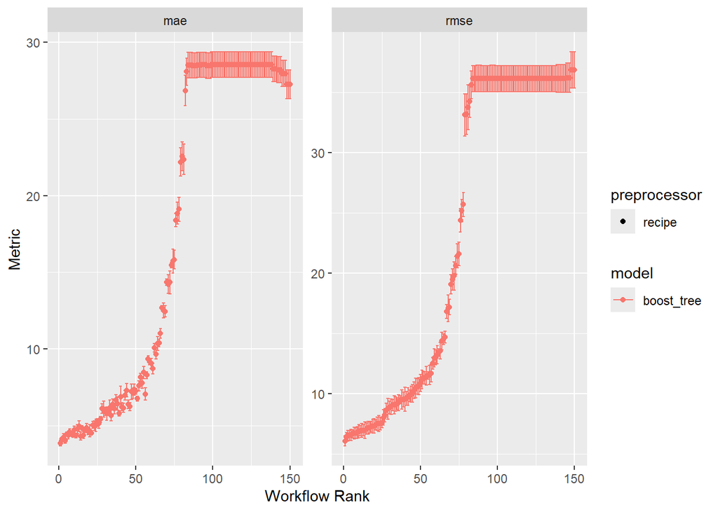

```r
autoplot(tune_results)
```

**Show and hide code**

```r
ranking <- rank_results(tune_results, rank_metric = "rmse", select_best = T)
ranking
```

```
# A tibble: 6 × 9
  wflow_id     .config      .metric  mean std_err     n preprocessor model  rank
  <chr>        <chr>        <chr>   <dbl>   <dbl> <int> <chr>        <chr> <int>
1 features_xgb pre0_mod48_… mae      3.84   0.106     5 recipe       boos…     1
2 features_xgb pre0_mod48_… rmse     6.08   0.261     5 recipe       boos…     1
3 base_xgb     pre0_mod27_… mae      4.22   0.165     5 recipe       boos…     2
4 base_xgb     pre0_mod27_… rmse     6.51   0.266     5 recipe       boos…     2
5 pca_xgb      pre0_mod48_… mae      4.57   0.123     5 recipe       boos…     3
6 pca_xgb      pre0_mod48_… rmse     6.72   0.296     5 recipe       boos…     3
```

**Show and hide code**

```r
best_combo <- tune_results |>  #combo = przepis i parametry
  rank_results(rank_metric = "rmse") |>
  filter(.metric == "rmse") |>
  slice_head(n = 1)

best_combo
```

```
# A tibble: 1 × 9
  wflow_id     .config      .metric  mean std_err     n preprocessor model  rank
  <chr>        <chr>        <chr>   <dbl>   <dbl> <int> <chr>        <chr> <int>
1 features_xgb pre0_mod48_… rmse     6.08   0.261     5 recipe       boos…     1
```

**Show and hide code**

```r
best_wf_id <- best_combo$wflow_id[1]

best_wf <- tune_results |>
  extract_workflow(best_wf_id)

best_params <- tune_results |>
  extract_workflow_set_result(best_wf_id) |>
  select_best(metric = "rmse")

best_params
```

```
# A tibble: 1 × 7
   mtry trees min_n tree_depth learn_rate loss_reduction .config
  <int> <int> <int>      <int>      <dbl>          <dbl> <chr>
1     5  1094    14          7    0.00725           41.5 pre0_mod48_post0
```

## 2.10 Finalizacja

Finalizacja workflowu XGB, dopasowanie do danych i ocena na zbiorze testowym.

**Show and hide code**

```r
final_xgb_wf <- finalize_workflow(best_wf, best_params)

print(final_xgb_wf)
```

```
══ Workflow ════════════════════════════════════════════════════════════════════
Preprocessor: Recipe
Model: boost_tree()

── Preprocessor ────────────────────────────────────────────────────────────────
9 Recipe Steps

• step_mutate()
• step_rm()
• step_string2factor()
• step_zv()
• step_dummy()
• step_mutate()
• step_YeoJohnson()
• step_normalize()
• step_zv()

── Model ───────────────────────────────────────────────────────────────────────
Boosted Tree Model Specification (regression)

Main Arguments:
  mtry = 5
  trees = 1094
  min_n = 14
  tree_depth = 7
  learn_rate = 0.00725487709502495
  loss_reduction = 41.5262163898016

Computational engine: xgboost
```

**Show and hide code**

```r
final_fit <- last_fit(final_xgb_wf, split = split)

print(collect_metrics(final_fit))
```

```
# A tibble: 2 × 4
  .metric .estimator .estimate .config
  <chr>   <chr>          <dbl> <chr>
1 rmse    standard      22.1   pre0_mod0_post0
2 rsq     standard       0.841 pre0_mod0_post0
```

**Show and hide code**

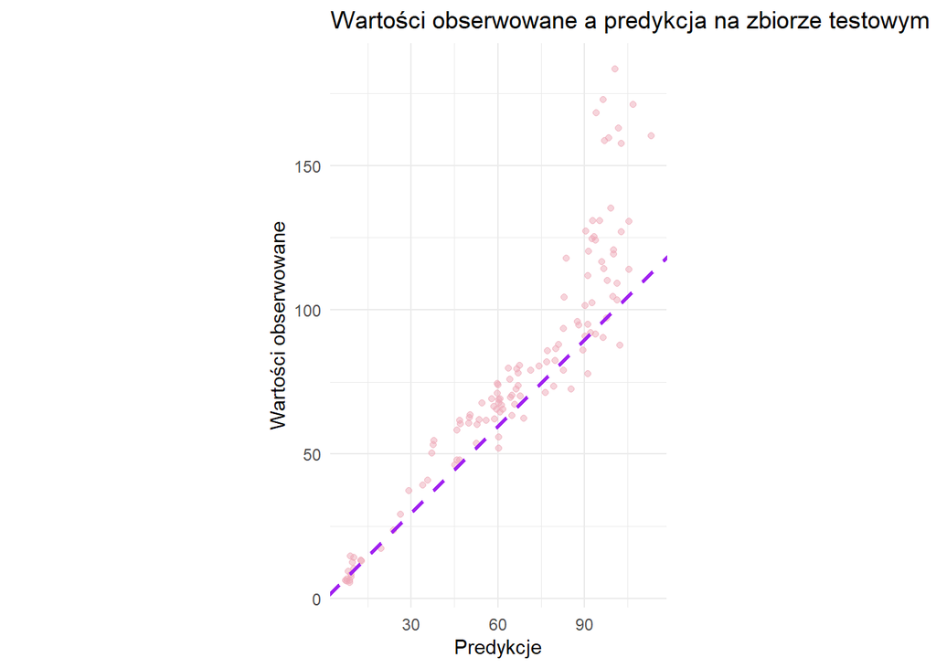

```r
test_pred <- collect_predictions(final_fit)

pred_plot <- ggplot(test_pred, aes(x = .pred, y = grimm_pm10)) +
  geom_point(alpha = 0.5, color = "pink2") +
  geom_abline(color = "purple", linetype = "dashed", linewidth = 1) +
  labs(
    title = "Wartości obserwowane a predykcja na zbiorze testowym",
    x = "Predykcje",
    y = "Wartości obserwowane"
  ) +
  theme_minimal() +
  coord_fixed()


print(pred_plot)
```

**Show and hide code**

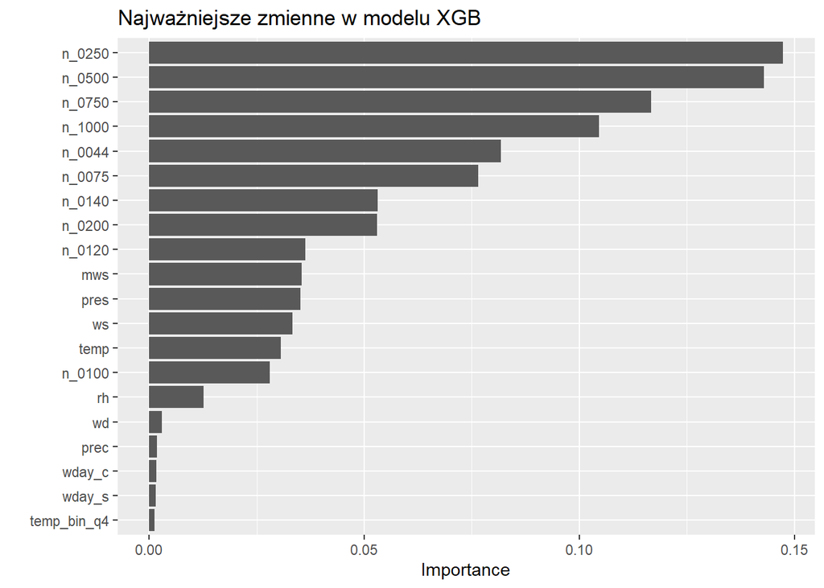

```r
wf_fitted <- final_fit$.workflow[[1]]

fit_parsnip <- tryCatch(
  extract_fit_parsnip(wf_fitted),
  error = function(e) {
    message("extract_fit_parsnip nie zadziałał, stosuję pull_workflow_fit()")
    pull_workflow_fit(wf_fitted)})

xgb_fit_engine <- fit_parsnip$fit

vip_plot <- vip(xgb_fit_engine, num_features = 20) +
  ggtitle("Najważniejsze zmienne w modelu XGB")

vip_plot
```

## 2.11 Wyniki XGB

**Show and hide code**

```r
if (!dir.exists("wyniki_xgb")) {
  dir.create("wyniki_xgb", recursive = TRUE)}

metryki_testowe <- collect_metrics(final_fit)
write_csv(metryki_testowe, "wyniki_xgb/metryki_testowe.csv")
write_csv(best_params, "wyniki_xgb/najlepsze_hiperparametry.csv")

final_workflow_fitted <- extract_workflow(final_fit)
saveRDS(final_workflow_fitted, "wyniki_xgb/final_xgb_workflow.rds")

train <- train_main
test <- test_main
to_drop <- to_drop_main
```

# 3 Model SVR

## 3.1 Lista zmiennych do usunięcia

**Show and hide code**

```r
to_drop <- character(0)

final_to_drop <- intersect(to_drop, names(train))
if ("poj_h" %in% names(train) && !("poj_h" %in% final_to_drop)) {
  final_to_drop <- c(final_to_drop, "poj_h")
}
```

## 3.2 RECEPTA 1: BAZOWA (bez interakcji)

**Show and hide code**

```r
rec_svr_base <- recipe(grimm_pm10 ~ ., data = train) |>
  update_role(date, new_role = "id") |>
  step_mutate(
    hour_s = sin(2*pi*as.numeric(hour)/24),
    hour_c = cos(2*pi*as.numeric(hour)/24),
    wday_s = sin(2*pi*as.numeric(wday)/7),
    wday_c = cos(2*pi*as.numeric(wday)/7)
  ) |>
  step_rm(hour, wday) |>
  step_rm(any_of(final_to_drop)) |>
  step_YeoJohnson(all_numeric_predictors()) |>
  step_normalize(all_numeric_predictors()) |>
  step_zv(all_predictors())
```

## 3.3 RECEPTA 2: INTERAKCJE POGODOWE — FIX

**Show and hide code**

```r
rec_svr_weather <- recipe(grimm_pm10 ~ ., data = train) |>
  update_role(date, new_role = "id") |>
  step_mutate(
    hour_s = sin(2*pi*as.numeric(hour)/24),
    hour_c = cos(2*pi*as.numeric(hour)/24),
    wday_s = sin(2*pi*as.numeric(wday)/7),
    wday_c = cos(2*pi*as.numeric(wday)/7),
    high_rh   = if ("rh"   %in% names(train)) rh   > median(rh,   na.rm = TRUE) else NA,
    high_temp = if ("temp" %in% names(train)) temp > median(temp, na.rm = TRUE) else NA,
    weather_type = case_when(
      isTRUE(high_rh) & isTRUE(high_temp) ~ "warm_humid",
      isTRUE(high_rh) & !isTRUE(high_temp) ~ "cold_humid",
      !isTRUE(high_rh) & isTRUE(high_temp) ~ "warm_dry",
      TRUE ~ "cold_dry"
    ),
    # >>> WYMUSZAMY STAŁE POZIOMY <<<
    weather_type = factor(weather_type,
                          levels = c("warm_humid","cold_humid","warm_dry","cold_dry"))
  ) |>
  step_rm(hour, wday, high_rh, high_temp) |>
  step_rm(any_of(final_to_drop)) |>
  step_dummy(all_nominal_predictors(), one_hot = TRUE) |>
  # >>> INTERAKCJE ZANIM COKOLWIEK USUNIEMY <<<
  step_interact(terms = ~ starts_with("weather_type_"):matches("^n_\\d+$")) |>
  step_interact(terms = ~ starts_with("weather_type_"):matches("^(ws|mws)$")) |>
  step_YeoJohnson(all_numeric_predictors()) |>
  step_normalize(all_numeric_predictors()) |>
  # >>> DOPIERO TERAZ PRUNING <<<
  step_zv(all_predictors())
```

## 3.4 RECEPTA 3: INTERAKCJE CZASOWE

**Show and hide code**

```r
rec_svr_temporal <- recipe(grimm_pm10 ~ ., data = train) |>
  update_role(date, new_role = "id") |>
  step_mutate(
    hour_s = sin(2*pi*as.numeric(hour)/24),
    hour_c = cos(2*pi*as.numeric(hour)/24),
    wday_s = sin(2*pi*as.numeric(wday)/7),
    wday_c = cos(2*pi*as.numeric(wday)/7),
    # Pory dnia
    time_of_day = case_when(
      as.numeric(hour) %in% 0:5 ~ "night",
      as.numeric(hour) %in% 6:11 ~ "morning",
      as.numeric(hour) %in% 12:17 ~ "afternoon",
      TRUE ~ "evening"
    ),
    # Weekend
    weekend = as.integer(as.numeric(wday) %in% c(6, 7))
  ) |>
  step_rm(hour, wday) |>
  step_rm(any_of(final_to_drop)) |>
  step_string2factor(time_of_day) |>
  step_novel(all_nominal_predictors()) |>
  step_dummy(all_nominal_predictors(), one_hot = TRUE) |>
  step_zv(all_predictors()) |>
  # Interakcje pora dnia x zliczenia
  step_interact(terms = ~ starts_with("time_of_day_"):matches("^n_\\d+$")) |>
  # Interakcje weekend x zliczenia + wiatr
  step_interact(terms = ~ weekend:matches("^n_\\d+$|^(ws|mws)$")) |>
  step_YeoJohnson(all_numeric_predictors()) |>
  step_normalize(all_numeric_predictors()) |>
  step_zv(all_predictors())
```

## 3.5 RECEPTA 4: KOMBINOWANE (pogoda + czas + temperatura)

**Show and hide code**

```r
rec_svr_combined <- recipe(grimm_pm10 ~ ., data = train) |>
  update_role(date, new_role = "id") |>
  step_mutate(
    hour_s = sin(2*pi*as.numeric(hour)/24),
    hour_c = cos(2*pi*as.numeric(hour)/24),
    wday_s = sin(2*pi*as.numeric(wday)/7),
    wday_c = cos(2*pi*as.numeric(wday)/7),
    temp_bin = if ("temp" %in% names(train)) cut(
      temp,
      breaks = quantile(temp, probs = seq(0, 1, 0.25), na.rm = TRUE),
      include.lowest = TRUE,
      labels = c("q1","q2","q3","q4")
    ) else NA_character_,
    high_rh = if ("rh" %in% names(train)) rh > median(rh, na.rm = TRUE) else NA,
    weather_humid = if_else(isTRUE(high_rh), "humid", "dry"),
    weekend = as.integer(as.numeric(wday) %in% c(6, 7)),
    # stałe poziomy
    temp_bin = factor(temp_bin, levels = c("q1","q2","q3","q4")),
    weather_humid = factor(weather_humid, levels = c("humid","dry"))
  ) |>
  step_rm(hour, wday, high_rh) |>
  step_rm(any_of(final_to_drop)) |>
  step_dummy(all_nominal_predictors(), one_hot = TRUE) |>
  step_interact(terms = ~ starts_with("temp_bin_"):matches("^n_(0250|0500|1000)$")) |>
  step_interact(terms = ~ starts_with("weather_humid_"):matches("^(ws|mws)$")) |>
  step_interact(terms = ~ weekend:matches("^n_(0250|0500|1000)$")) |>
  step_YeoJohnson(all_numeric_predictors()) |>
  step_normalize(all_numeric_predictors()) |>
  step_zv(all_predictors())
```

## 3.6 MODEL SVR I TUNING

**Show and hide code**

```r
# Definicja modelu SVR
svr_spec <- svm_rbf(
  cost = tune(),
  rbf_sigma = tune()
) |>
  set_engine("kernlab") |>
  set_mode("regression")

# Workflow
svr_workflows <- list(
  svr_base = workflow() |> add_recipe(rec_svr_base) |> add_model(svr_spec),
  svr_weather = workflow() |> add_recipe(rec_svr_weather) |> add_model(svr_spec),
  svr_temporal = workflow() |> add_recipe(rec_svr_temporal) |> add_model(svr_spec),
  svr_combined = workflow() |> add_recipe(rec_svr_combined) |> add_model(svr_spec)
)
```

## 3.7 Walidacja krzyżowa

**Show and hide code**

```r
cv_folds <- vfold_cv(train, v = 5, strata = grimm_pm10)
```

## 3.8 Siatka hiperparametrów

Definicja siatki hiperparametrów i metryk dla SVR.

**Show and hide code**

```r
svr_grid <- expand.grid(
  cost = 10^seq(-1, 2, length.out = 4),
  rbf_sigma = 10^seq(-3, 0, length.out = 4)
) |> as_tibble()

svr_metrics <- metric_set(rmse, rsq, mae)
```

## 3.9 Tuning

Uruchomienie procesu strojenia dla wszystkich wariantów SVR.

**Show and hide code**

```r
tic()

svr_tune_results <- imap(
  svr_workflows,
  ~ {
    set.seed(42)
    tune_grid(
      .x,
      resamples = cv_folds,
      grid = svr_grid,
      metrics = svr_metrics,
      control = control_grid(verbose = FALSE, save_pred = TRUE)
    )
  }
)

toc()
```

```
114.68 sec elapsed
```

## 3.10 WYNIKI I WYBÓR NAJLEPSZEGO MODELU

**Show and hide code**

```r
best_models_summary <- map_dfr(
  svr_tune_results,
  ~ {
    best_rmse <- show_best(.x, metric = "rmse", n = 1)
    best_rsq <- show_best(.x, metric = "rsq", n = 1)
    best_mae <- show_best(.x, metric = "mae", n = 1)

    if (nrow(best_rmse) > 0) {
      tibble(
        mean_rmse = best_rmse$mean[1],
        std_err_rmse = best_rmse$std_err[1],
        mean_rsq = if(nrow(best_rsq) > 0) best_rsq$mean[1] else NA_real_,
        mean_mae = if(nrow(best_mae) > 0) best_mae$mean[1] else NA_real_,
        cost = best_rmse$cost[1],
        rbf_sigma = best_rmse$rbf_sigma[1]
      )
    } else {
      tibble(
        mean_rmse = NA_real_,
        std_err_rmse = NA_real_,
        mean_rsq = NA_real_,
        mean_mae = NA_real_,
        cost = NA_real_,
        rbf_sigma = NA_real_
      )
    }
  },
  .id = "recipe"
) |>
  mutate(recipe = str_remove(recipe, "svr_")) |>
  filter(!is.na(mean_rmse)) |>
  arrange(mean_rmse)

print(best_models_summary, n = Inf)
```

```
# A tibble: 4 × 7
  recipe   mean_rmse std_err_rmse mean_rsq mean_mae  cost rbf_sigma
  <chr>        <dbl>        <dbl>    <dbl>    <dbl> <dbl>     <dbl>
1 base          4.64        0.740    0.982     3.06   100     0.01
2 weather       4.66        0.652    0.982     3.06    10     0.01
3 combined      6.06        1.03     0.969     3.51    10     0.01
4 temporal      6.78        2.06     0.963     3.72   100     0.001
```

## 3.11 Wybór najlepszego modelu

**Show and hide code**

```r
best_recipe_name <- best_models_summary$recipe[1]
best_full_name <- paste0("svr_", best_recipe_name)
best_results <- svr_tune_results[[best_full_name]]
best_svr_params <- select_best(best_results, metric = "rmse")

best_full_name
```

```
[1] "svr_base"
```

**Show and hide code**

```r
print(best_svr_params)
```

```
# A tibble: 1 × 3
   cost rbf_sigma .config
  <dbl>     <dbl> <chr>
1   100      0.01 pre0_mod14_post0
```

## 3.12 Finalizacja workflow

**Show and hide code**

```r
best_svr_wf <- svr_workflows[[best_full_name]] |>
  finalize_workflow(best_svr_params)

tic()
final_svr_fit <- fit(best_svr_wf, data = train)
toc()
```

```
0.24 sec elapsed
```

## 3.13 Wyniki SVR

**Show and hide code**

```r
if (!dir.exists("wyniki")) {
  dir.create("wyniki", recursive = TRUE)
}

saveRDS(svr_tune_results, "wyniki/svr_tune_results.rds")
saveRDS(final_svr_fit, "wyniki/final_svr_model.rds")
saveRDS(best_models_summary, "wyniki/best_models_summary.rds")
```

# 4 Model LR

**Show and hide code**

```r
train <- train_main
test <- test_main
to_drop <- to_drop_main

target <- "grimm_pm10"

n <- nrow(train_tr)
initial <- floor(0.6 * n)
assess  <- floor(0.2 * n)
skip    <- floor(0.05 * n)

ts_cv <- rolling_origin(
  data = train_tr,
  initial = initial,
  assess = assess,
  cumulative = TRUE,
  skip = skip
)

length(ts_cv$splits)
```

```
[1] 4
```

## 4.1 Receipe

**Show and hide code**

```r
rec <- recipe(grimm_pm10 ~ ., data = train_tr) %>%
  step_zv(all_predictors()) %>%             # usuń predyktory bez zmienności
  step_dummy(all_nominal_predictors()) %>%  # zamień zmienne kategoryczne na zmienne 0/1
  step_normalize(all_numeric_predictors())  # standaryzacja zmiennych numerycznych
```

## 4.2 Regresja liniowa i workflow

**Show and hide code**

```r
lm_spec <- linear_reg() %>%
  set_engine("lm")

lm_wf <- workflow() %>%
  add_model(lm_spec) %>%
  add_recipe(rec)
```

## 4.3 Walidacja z użyciem rolling-origin CV

**Show and hide code**

```r
lm_resamples <- fit_resamples(
  lm_wf,
  resamples = ts_cv,
  metrics = metric_set(rmse, rsq, mae),
  control = control_resamples(save_pred = TRUE)
)

collect_metrics(lm_resamples)
```

```
# A tibble: 3 × 6
  .metric .estimator   mean     n std_err .config
  <chr>   <chr>       <dbl> <int>   <dbl> <chr>
1 mae     standard   26.3       4  1.55   pre0_mod0_post0
2 rmse    standard   40.3       4  2.44   pre0_mod0_post0
3 rsq     standard    0.282     4  0.0624 pre0_mod0_post0
```

**Show and hide code**

```r
lm_preds <- collect_predictions(lm_resamples)
```

## 4.4 Trenowanie finalnego modelu na całym zbiorze treningowym

**Show and hide code**

```r
lm_final <- lm_wf %>%
  fit(data = train_tr)

tidy(lm_final %>% extract_fit_parsnip())
```

```
# A tibble: 126 × 5
   term        estimate     std.error statistic  p.value
   <chr>          <dbl>         <dbl>     <dbl>    <dbl>
 1 (Intercept) -5.26e+3 1905.            -2.76  5.98e- 3
 2 date         3.23e-6    0.00000116     2.78  5.59e- 3
 3 n_0044       1.49e+1    1.02          14.5   3.87e-40
 4 n_0140       3.91e+0    0.831          4.71  3.27e- 6
 5 n_0500       6.26e+0    1.35           4.64  4.36e- 6
 6 temp        -2.20e+0    2.19          -1.01  3.14e- 1
 7 rh          -3.72e+0    1.07          -3.48  5.53e- 4
 8 pres        -2.70e-1    0.623         -0.434 6.65e- 1
 9 wd          -1.70e+0    0.508         -3.34  9.02e- 4
10 mws         -7.37e+0    1.56          -4.74  2.84e- 6
# ℹ 116 more rows
```

## 4.5 Obliczenie współczynników i VIF

**Show and hide code**

```r
lm_obj <- lm_final %>% pull_workflow_fit() %>% .$fit
vif_safe <- function(model) { # obejście błędu przy car::vif()
  mm <- model.matrix(model)
  mm <- mm[, !is.na(coef(model))]
  car::vif(lm(model$y ~ mm - 1))
}
train_tr_lm <- train_tr
test_tr_lm  <- test_tr
```

## 4.6 Predykcje i reszty dla zbioru treningowego

**Show and hide code**

```r
train_tr_lm$.fitted <- predict(lm_obj)
train_tr_lm$.resid  <- residuals(lm_obj)

train_tr_ml <- train_tr %>% select(-any_of(c(".fitted", ".resid")))
test_tr_ml  <- test_tr  %>% select(-any_of(c(".fitted", ".resid")))
```

## 4.7 Wykres

**Show and hide code**

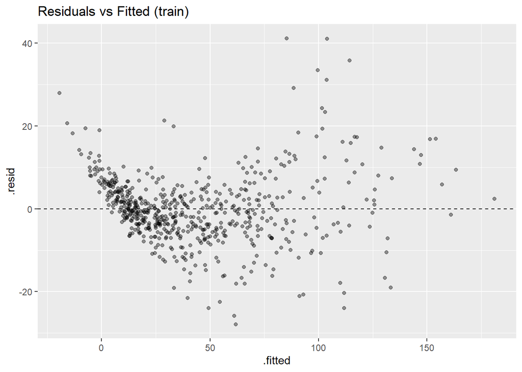

```r
ggplot(train_tr_lm, aes(.fitted, .resid)) +
  geom_point(alpha = 0.4) +
  geom_hline(yintercept = 0, linetype = "dashed") +
  labs(title = "Residuals vs Fitted (train)")
```

**Show and hide code**

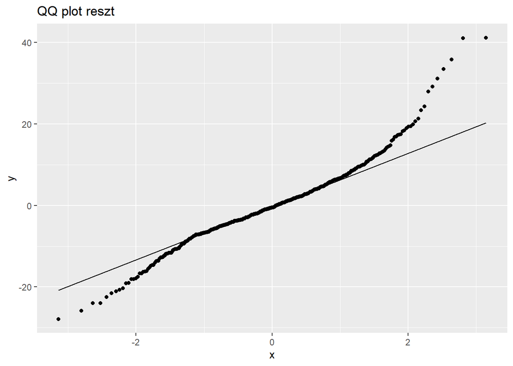

```r
ggplot(train_tr_lm, aes(sample = .resid)) +
  stat_qq() +
  stat_qq_line() +
  labs(title = "QQ plot reszt")
```

**Show and hide code**

```r
shapiro_test <- shapiro.test(train_tr_lm$.resid[1:min(5000, nrow(train_tr_lm))])
print(shapiro_test)
```

```
    Shapiro-Wilk normality test

data:  train_tr_lm$.resid[1:min(5000, nrow(train_tr_lm))]
W = 0.95397, p-value = 9.428e-13
```

## 4.8 Predykcje i metryki na zbiorze testowym

**Show and hide code**

```r
test_pred_lm <- predict(lm_obj, newdata = test_tr_ml) %>%
  bind_cols(test_tr_ml %>% select(all_of(target)))

test_pred_lm <- tibble(
  .pred = predict(lm_obj, newdata = test_tr_ml),
  !!target := test_tr_ml[[target]]
)

metrics_test_lm <- metric_set(rmse, rsq, mae)(
  test_pred_lm, truth = !!sym(target), estimate = .pred
)
print("Metryki LM na zbiorze testowym:")
```

```
[1] "Metryki LM na zbiorze testowym:"
```

**Show and hide code**

```r
print(metrics_test_lm)
```

```
# A tibble: 3 × 3
  .metric .estimator .estimate
  <chr>   <chr>          <dbl>
1 rmse    standard      15.6
2 rsq     standard       0.743
3 mae     standard      11.6
```

## 4.9 Wykres: przewidywane wartości

**Show and hide code**

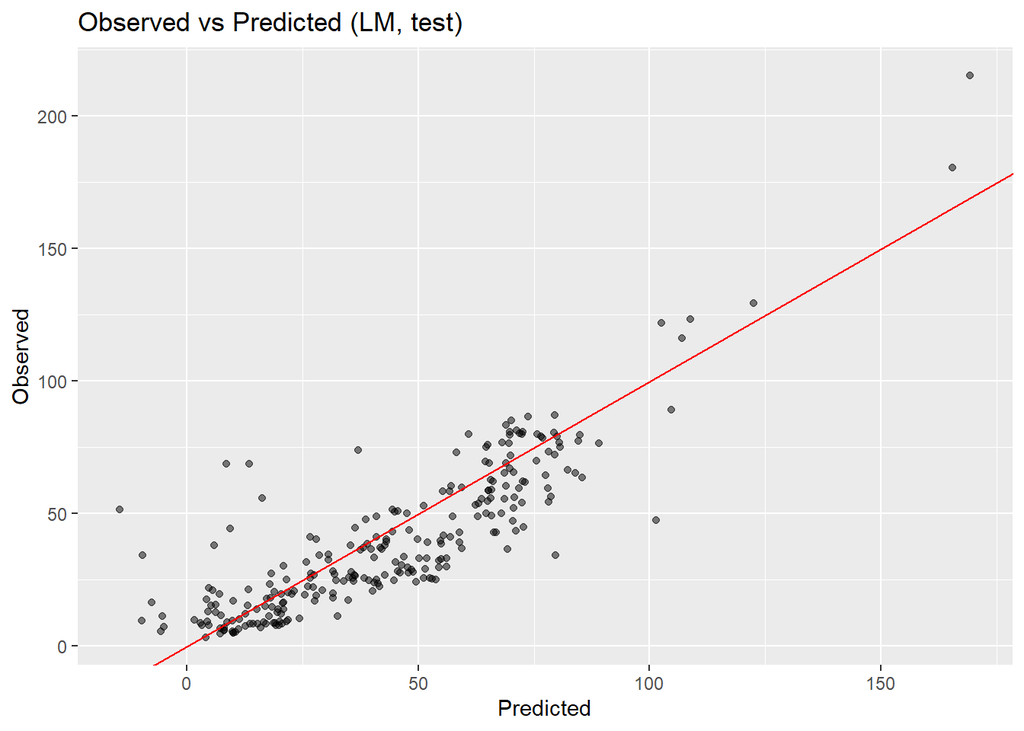

```r
ggplot(test_pred_lm, aes(x = .pred, y = !!sym(target))) +
  geom_point(alpha = 0.5) +
  geom_abline(slope = 1, intercept = 0, color = "red") +
  labs(title = "Observed vs Predicted (LM, test)", x = "Predicted", y = "Observed")
```

## 4.10 Współczynniki regresji (posortowane wg wartości p)

**Show and hide code**

```r
lm_coefs <- tidy(lm_obj) %>% arrange(p.value)
print("Główne współczynniki (LM):")
```

```
[1] "Główne współczynniki (LM):"
```

**Show and hide code**

```r
print(head(lm_coefs, 20))
```

```
# A tibble: 20 × 5
   term                                    estimate std.error statistic  p.value
   <chr>                                      <dbl>     <dbl>     <dbl>    <dbl>
 1 n_0044                                     14.9      1.02      14.5  3.87e-40
 2 weather_type_warm_dry_x_n_0500             17.2      1.47      11.8  2.27e-28
 3 hour_cat_evening_x_n_0500                  10.4      1.25       8.30 9.17e-16
 4 hour_cat_morning_x_n_0500                  11.2      1.58       7.10 4.16e-12
 5 hour_cat_morning_x_weather_type_warm_d…    -9.38     1.38      -6.82 2.62e-11
 6 hour_cat_morning_x_weather_type_warm_d…     6.28     1.11       5.64 2.82e- 8
 7 hour_cat_night_x_weather_type_warm_dry…     5.22     0.987      5.29 1.80e- 7
 8 hour_cat_night                            -64.4     12.4       -5.20 2.89e- 7
 9 hour_cat_evening_x_weather_type_warm_d…    -5.49     1.12      -4.92 1.19e- 6
10 mws                                        -7.37     1.56      -4.74 2.84e- 6
11 n_0140                                      3.91     0.831      4.71 3.27e- 6
12 n_0500                                      6.26     1.35       4.64 4.36e- 6
13 wday_s                                      2.25     0.494      4.55 6.63e- 6
14 hour_cat_night_x_mws                       55.4     12.3        4.52 7.82e- 6
15 weather_type_cool_humid                    45.7     10.9        4.18 3.48e- 5
16 weather_type_cool_humid_x_mws             -48.4     11.8       -4.11 4.59e- 5
17 hour_cat_evening                          -54.5     13.4       -4.06 5.77e- 5
18 hour_cat_evening_x_weather_type_warm_d…     3.89     1.10       3.53 4.52e- 4
19 rh                                         -3.72     1.07      -3.48 5.53e- 4
20 temp_bin_Q2_x_weather_type_cool_humid_…   129.      37.2        3.46 5.90e- 4
```

## 4.11 Zapis wyników

**Show and hide code**

```r
if (!dir.exists("wyniki_lr")) {
  dir.create("wyniki_lr", recursive = TRUE)
}

saveRDS(lm_resamples, "wyniki/lm_resamples.rds")
saveRDS(lm_final, "wyniki/lm_final_model.rds")
saveRDS(metrics_test_lm, "wyniki/lm_test_metrics.rds")
saveRDS(lm_coefs, "wyniki/lm_coefficients.rds")
```

# 5 XGB, SVR, LR Models comparison

## 5.1 Wczytanie najlepszych modeli i generowanie predykcji

**Show and hide code**

```r
metrics_set <- metric_set(rmse, rsq, mae)

wszystkie_predykcje <- tibble()
wszystkie_metryki <- tibble()

# Model 1 - XGBoost
xgb_model_path <- "wyniki_xgb/final_xgb_workflow.rds"
if (file.exists(xgb_model_path)) {
  message("Wczytuję model XGB...")
  xgb_final_wf <- readRDS(xgb_model_path)

  # Generowanie predykcji na `test`
  xgb_preds <- predict(xgb_final_wf, new_data = test) |>
    bind_cols(test |> select(grimm_pm10, date)) |>
    mutate(model = "XGBoost")

  # Obliczanie metryk
  xgb_metrics <- metrics_set(xgb_preds, truth = grimm_pm10, estimate = .pred) |>
    mutate(model = "XGBoost")

  wszystkie_predykcje <- bind_rows(wszystkie_predykcje, xgb_preds)
  wszystkie_metryki <- bind_rows(wszystkie_metryki, xgb_metrics)

} else {
  warning("Nie znaleziono zapisanego modelu XGB: ", xgb_model_path)
}

# Model 2 - SVR
svr_model_path <- "wyniki/final_svr_model.rds"
if (file.exists(svr_model_path)) {
  message("Wczytuję model SVR...")
  svr_final_fit <- readRDS(svr_model_path)

  # Generowanie predykcji na `test`
  svr_preds <- predict(svr_final_fit, new_data = test) |>
    bind_cols(test |> select(grimm_pm10, date)) |>
    mutate(model = "SVR")

  # Obliczanie metryk
  svr_metrics <- metrics_set(svr_preds, truth = grimm_pm10, estimate = .pred) |>
    mutate(model = "SVR")

  wszystkie_predykcje <- bind_rows(wszystkie_predykcje, svr_preds)
  wszystkie_metryki <- bind_rows(wszystkie_metryki, svr_metrics)

} else {
  warning("Nie znaleziono zapisanego modelu SVR: ", svr_model_path)
}

# Model 3 - LR
lr_model_path <- "wyniki/lm_final_model.rds"
if (file.exists(lr_model_path)) {
  message("Wczytuję model LR...")
  lr_final_model <- readRDS(lr_model_path)

  test_tr

  # WAŻNE: Model LR był trenowany na `train_tr`, więc predykcje robimy na `test_tr`
  lr_preds <- predict(lr_final_model, new_data = test_tr) |>
    bind_cols(test_tr |> select(grimm_pm10, date)) |> # `date` jest w `test_tr` jako "id"
    mutate(model = "Linear Regression")

  # Obliczanie metryk
  lr_metrics <- metrics_set(lr_preds, truth = grimm_pm10, estimate = .pred) |>
    mutate(model = "Linear Regression")

  wszystkie_predykcje <- bind_rows(wszystkie_predykcje, lr_preds)
  wszystkie_metryki <- bind_rows(wszystkie_metryki, lr_metrics)

} else {
  warning("Nie znaleziono zapisanego modelu LR: ", lr_model_path)
}
```

## 5.2 Porównanie wyników

Tabelaryczne i graficzne porównanie metryk (RMSE, R-squared, MAE) dla wszystkich trzech modeli na zbiorze testowym.

**Show and hide code**

```r
metryki_tabela <- wszystkie_metryki |>
  pivot_wider(names_from = .metric, values_from = .estimate) |>
  arrange(rmse)

print(knitr::kable(metryki_tabela, digits = 4))
```

```
|.estimator |model             |    rmse|    rsq|     mae|
|:----------|:-----------------|-------:|------:|-------:|
|standard   |SVR               |  8.9776| 0.9205|  6.7234|
|standard   |XGBoost           | 11.0866| 0.8605|  5.5657|
|standard   |Linear Regression | 15.6064| 0.7425| 11.6131|
```

**Show and hide code**

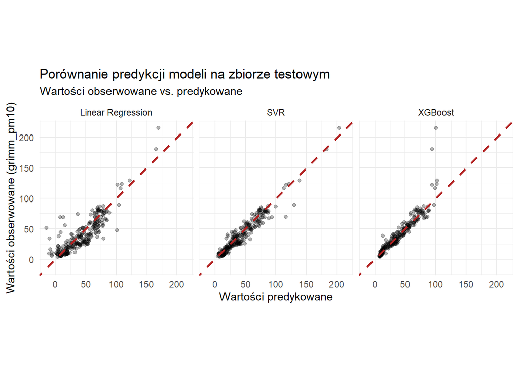

```r
if (nrow(wszystkie_predykcje) > 0) {

  diag_line <- geom_abline(
    color = "firebrick",
    linetype = "dashed",
    linewidth = 1
  )

  min_val <- min(c(wszystkie_predykcje$.pred, wszystkie_predykcje$grimm_pm10), na.rm = TRUE)
  max_val <- max(c(wszystkie_predykcje$.pred, wszystkie_predykcje$grimm_pm10), na.rm = TRUE)
  lims <- c(min_val, max_val)

  plot_comparison <- ggplot(wszystkie_predykcje, aes(x = .pred, y = grimm_pm10)) +
    geom_point(alpha = 0.3) +
    diag_line +
    facet_wrap(~ model) +
    coord_fixed(ratio = 1, xlim = lims, ylim = lims) +
    labs(
      title = "Porównanie predykcji modeli na zbiorze testowym",
      subtitle = "Wartości obserwowane vs. predykowane",
      x = "Wartości predykowane",
      y = "Wartości obserwowane (grimm_pm10)"
    ) +
    theme_minimal()

  print(plot_comparison)

  # Zapis wykresu
  # ggsave("wyniki/porownanie_predykcji_test.png", plot_comparison, width = 10, height = 5, dpi = 300)

} else {
  message("Brak danych predykcyjnych do wygenerowania wykresu.")
}
```

**Show and hide code**

```r
najlepszy_model <- metryki_tabela |>
  slice_min(rmse, n = 1) |>
  pull(model)
```

# 6 Weryfikacja danych na zbiorze BAM

**Show and hide code**

```r
load("dane/ops.RData")
load("dane/data_test.RData")

final_model <- xgb_final_wf
uzyty_model <- "XGBoost"
```

**Show and hide code**

```r
weryfikacja <- ops_data |> select(date:prec)
# wyciągasz z ops_data tylko daty i dane meteo

weryfikacja <- weryfikacja |>
  left_join(bam, by = "date") |>
  mutate(grimm_pm10 = bam_pm10) |>
  select(-bam_pm10)
# dodajesz dane BAM i podmieniasz nazwę kolumny bam_pm10 na grimm_pm10
# (żeby struktura była taka sama jak w danych treningowych)

ops <- ops |> select(-ops_pm10, -pres_sea)
# usuwasz kolumny niepotrzebne przy predykcji

nazwy <- colnames(ops) |> dput()
```

```
c("date", "grimm_pm10", "n_0044", "n_0075", "n_0100", "n_0120",
"n_0140", "n_0200", "n_0250", "n_0500", "n_0750", "n_1000", "temp",
"rh", "pres", "wd", "mws", "ws", "prec")
```

**Show and hide code**

```r
weryfikacja <- weryfikacja |>
  select(all_of(nazwy))

colnames(weryfikacja) == colnames(ops)
```

```
 [1] TRUE TRUE TRUE TRUE TRUE TRUE TRUE TRUE TRUE TRUE TRUE TRUE TRUE TRUE TRUE
[16] TRUE TRUE TRUE TRUE
```

**Show and hide code**

```r
weryfikacja <-weryfikacja |> na.omit()
```

## 6.1 Uzupełnienie ewentualnych brakujących kolumn (np. hour, wday)

**Show and hide code**

```r
if(!"hour" %in% names(weryfikacja)){
  weryfikacja <- weryfikacja |> mutate(hour = lubridate::hour(date))
}
if(!"wday" %in% names(weryfikacja)){
  weryfikacja <- weryfikacja |> mutate(wday = lubridate::wday(date))
}
```

## 6.2 Wypełnienie NA medianami (jak w treningu)

**Show and hide code**

```r
weryfikacja <- weryfikacja |>
  mutate(across(where(is.numeric), ~ ifelse(is.na(.), median(., na.rm = TRUE), .)))
```

## 6.3 Predykcja

**Show and hide code**

```r
weryfikacja_preds <- predict(final_model, new_data = weryfikacja) |>
  bind_cols(weryfikacja |> select(date, grimm_pm10))

metrics_set <- yardstick::metric_set(rmse, rsq, mae)

metryki_weryfikacja <- metrics_set(
  data = weryfikacja_preds,
  truth = grimm_pm10,
  estimate = .pred
)

print(metryki_weryfikacja)
```

```
# A tibble: 3 × 3
  .metric .estimator .estimate
  <chr>   <chr>          <dbl>
1 rmse    standard       6.65
2 rsq     standard       0.846
3 mae     standard       4.53
```

**Show and hide code**

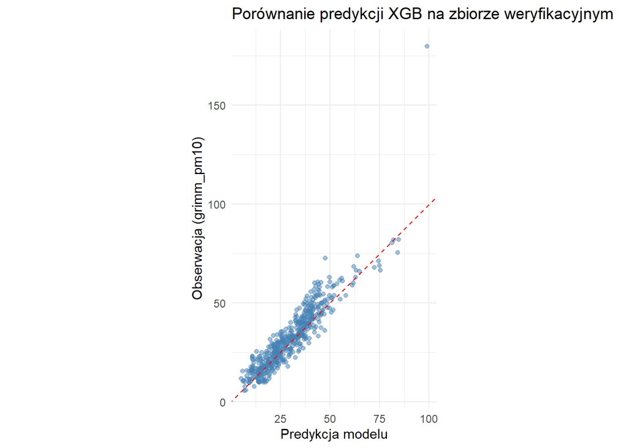

```r
ggplot(weryfikacja_preds, aes(x = .pred, y = grimm_pm10)) +
  geom_point(alpha = 0.5, color = "steelblue") +
  geom_abline(linetype = "dashed", color = "red") +
  coord_fixed() +
  labs(
    title = "Porównanie predykcji XGB na zbiorze weryfikacyjnym",
    x = "Predykcja modelu",
    y = "Obserwacja (grimm_pm10)"
  ) +
  theme_minimal()
```

# 7 Wnioski

# 8 Wnioski z analizy modeli

Celem analizy było znalezienie najlepszego modelu regresyjnego do przewidywania stężenia **`grimm_pm10`**.  
Porównano trzy algorytmy: **Regresję Liniową (LR)**, **Support Vector Regression (SVR)** oraz **XGBoost (XGB)**.

## 8.1 1. Najlepsze przepisy (receptury)

### 8.1.2 🟦 Support Vector Regression (SVR)

- Najskuteczniejszy okazał się prostszy, bazowy przepis **`svr_base`**,  
  który zawierał m.in.:
  - transformacje trygonometryczne czasu,
  - normalizację danych.

### 8.1.3 🟨 Regresja Liniowa (LR)

- Model ten korzystał z podstawowego przepisu, który obejmował m.in.:
  - usunięcie zmiennych skorelowanych,
  - transformację **Yeo-Johnsona**.

## 8.2 2. Wybór najlepszego modelu

Porównanie metryk na zbiorze testowym:

| Model | RMSE | R-squared (R²) | MAE |
| --- | --- | --- | --- |
| SVR | 8.98 | 0.921 | 6.72 |
| XGBoost | 11.09 | 0.861 | 5.57 |
| Linear Regression | 15.61 | 0.743 | 11.61 |

**Wnioski:** 1. Regresja Liniowa była najsłabszym modelem.  
2. SVR uzyskał najlepsze wyniki pod kątem RMSE i R-squared.  
3. XGBoost osiągnął najlepszą (najniższą) metrykę MAE (Mean Absolute Error).

**Ostatecznie wybrano model XGBoost** do dalszej weryfikacji — dlatego, że metryka **MAE** jest mniej wrażliwa na wartości odstające, co jest pożądane w danych o zanieczyszczeniach.

## 8.3 3. Weryfikacja na zbiorze “BAM”

**Cel:**  
Sprawdzenie, jak wybrany model **XGBoost** poradzi sobie z zupełnie nowymi, zewnętrznymi danymi (ze stacji BAM), których nie widział podczas treningu.

| Metryka | Wartość |
| --- | --- |
| RMSE | 6.65 |
| R² | 0.846 |
| MAE | 4.53 |